# Programming in R: coursework

Chris Clements

2025

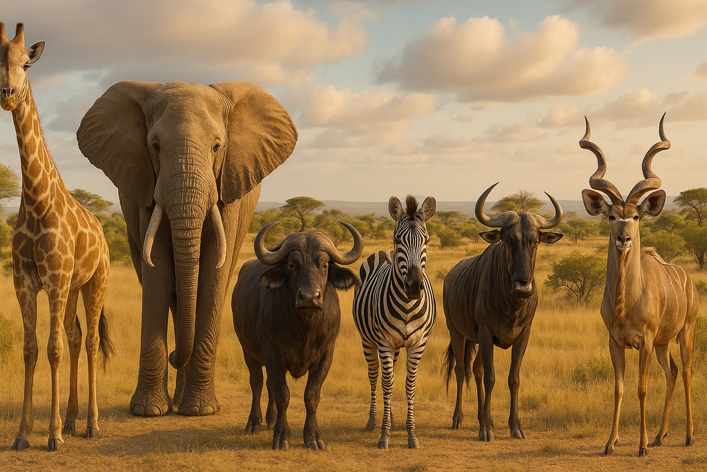

# 1 Background

Body mass is a key predictor of the health of an individual and the longevity of a population (Clements & Ozgul 2016, Cerini et al. 2023), as such understanding what impacts the body mass of an individual is a key goal in conservation biology if we are to maintain healthy wildlife populations into the future.

This is particular true for ungulate species in Africa which play a vital role in maintaining ecosystems by influencing vegetation structure, nutrient cycling, and predator-prey dynamics. Through their grazing and browsing behaviors, they help control plant growth, prevent bush encroachment, and promote biodiversity. Their dung enriches soil fertility, supporting plant regeneration and insect populations. Additionally, ungulates serve as key prey for large carnivores, maintaining the balance of predator populations. Seasonal migrations also shape ecosystem processes over large landscapes. Without wild ungulates, many ecosystems would degrade, losing their resilience, productivity, and the intricate web of life they support, suggesting that maintaining their populations is crucial for ecological stability in Africa.

# 2 The problem

It has been proposed that the survival of individuals, and thus the persistence of the population, is highly reliant on the body mass of the individuals in the population. However, we as yet do not have a clear understanding of the factors which drive changes in body mass in wild African ungulate populations. Your task is to determine what factors are the key drivers of body mass in your data, whilst accounting for any factors which may systematically bias your results.

# 3 The data

Each of you will receive an unique data set on the body mass of one of the wild African ungulates (Giraffe, Elephant, Buffalo, Zebra, Wildebeest, Kudu). Each body_mass row is a single measure from a different individual of the described species. These data are downloadable [here](https://github.com/ExperimentalConservation/R-coursework-data) and also include other potential variables of interest:

- “average_annual_rainfall_mm” - average annual rainfall in mm
- “mean_annual_temperature_celsius” - average annual temperature in celcius
- “vegetation_biomass_kg_per_ha” - amount of vegetation biomass per hectare in KG
- “distance_to_water_km” - distance to water from the place the data were collected
- “soil_nutrient_index” - a measure of soil nutrition
- “elevation_meters” - the elevation of the location the data were collected
- “observer” - who collected the data
- “predator_density_per_sq_km” - the number of predators (of all types) per square kilometer
- “human_disturbance_index” - a measure of how disturbed the habitat is by humans
- “habitat” - whether the habitat is savanna, woodland, or desert
- “tourism” - how much tourism the site sees
- “park” - which park these data were collected at
- “lion_presence” - whether there are lions present at the site
- “declining” - whether the population of the ungulate is declining
- “seasonailty” - whether the body mass measurement was taken during the wet or dry seasion
- “landscape” - the topography of the landscape
- “vegetation” - whether the habitat is “open” savanna or “dense” woody savanna
- “protection_status” - whether the population of ungulates is protected
- “migratory_status” - whether the population of ungulates is migratory or resident

# 4 Task

You need to demonstrate what the determinants of body mass in your wild ungulate species are, using any statistical modelling frameworks you think are appropriate. You must write a report showing:

1. how you read, manipulated (where appropriate), and visualized the data you are working with
2. what statistical tools you used to analyse these data and why these tools are justified (considering things like model structure and error distribution)
3. what determines the mass of your ungulate species (including any evidence to support your claims)

Please ensure you show all of the code you used to make these calculations and graphics, and note that the data provided to each of you is different to everyone else’s data, both in terms of the structure and what (if any) effects may be significant.

This report should be written in the style of the workbooks you are familiar with from the R course, and must contain no more than 5000 words (*including all code, code comments, and explanatory text*). The report should demonstrate the skills and best practices you have learnt over the Programming in R course: demonstrating your ability to write precise and concise R code, and to present your results in a format which other people can understand and check (you may want to use the Rmarkdown workbooks from the course as inspiration). Where appropriate you should include and interpret the outputs of statistical models so the reader can judge whether you have fitted appropriate models and whether your conclusions are justified.

# 5 Submission

Submission should be in the form of a .zip document containing both the rmarkdown file and the html output.

The deadline for this coursework is the **1pm on 19th December 2025**.

# 6 References

- Clements & Ozgul (2016) Nature communications 7 (1), 10984
- Cerini et al. (2023) Nature Ecology & Evolution 7 (3), 320-331